# Wrangle and Analyse Data (WeRateDogs).

## by Ayodele Ayodeji Fortunate

## Investigation Overview

> In this investigation, I wanted to know the top 10 Dogs with highest favourite count, Dog_stage with highest favourite_count and retweet_count and finally, year with the highest favorite count and the Dog who had the win.

## Dataset Overview

> This dataset is the tweet archive of Twitter user @dog_rates, also known as WeRateDogs. WeRateDogs is a Twitter account that rates people's dogs with a humorous comment about the dog. These ratings almost always have a denominator of 10. The numerators, though? Almost always greater than 10. 11/10, 12/10, 13/10, etc. Why? Because "they're good dogs Brent." WeRateDogs has over 4 million followers and has received international media coverage. This dataset archive contains basic tweet data tweet ID, timestamp, text among others for all 5000+ of their tweets as they stood on August 1, 2017.

3 datasets I worked with include:

- twitter_archive_enhanced.csv
- image_predictions.tsv
- tweet_json.txt

  > Data wrangling processes was done on these 3 datasets used for the analysis to create interesting and trustworthy analyses and visualizations.

## Top 10 Dogs with highest favourite count

> Checking out the top 10 Dogs with highest favourite counts, I found out that, 3 Dogs with name Duddles, Stephan and Jamesy with tweet_id 879415818425184262, 807106840509214720 and 866450705531457537 respectively has a really close favorite_count.
- Duddles has the highest favorite_count of 107956.0
- Stephan has favorite_count of 107015.0
- Jamesy has favorite_count of 106827.0

  > Based on my analysis, Duddles with tweet_id 879415818425184262 has the highest favorite_count of 107956.0

This can be observed from the visual in the next slide

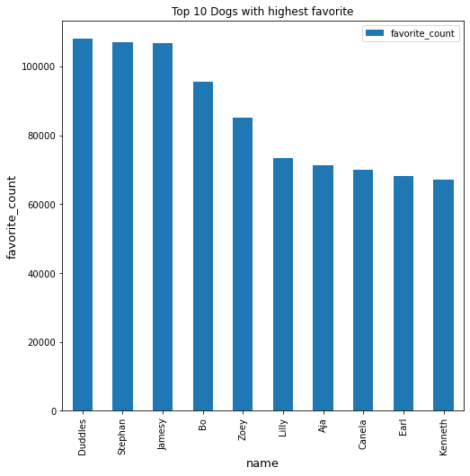

## Dog Stage with Highest Favourite Count and Retweet Count

> But Dog stage with name doggo and puppo has the highest favorite_count and retweet_count this can be seen clearly in the chat in the next slide.

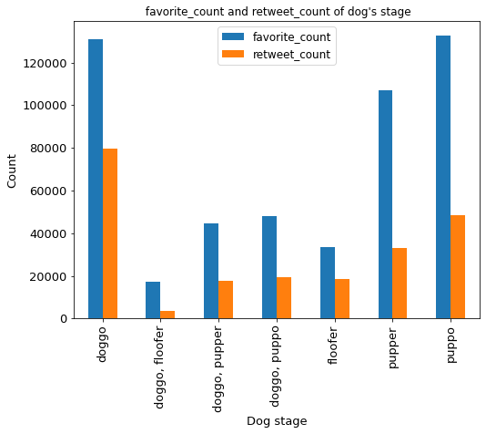

## Year with the highest favorite count and the Dog who had the win

> As for the year with highest favourite, My analysis shows that the year 2017 has highest favorite count of 107956.0 The Dog with name Duddles has the win.

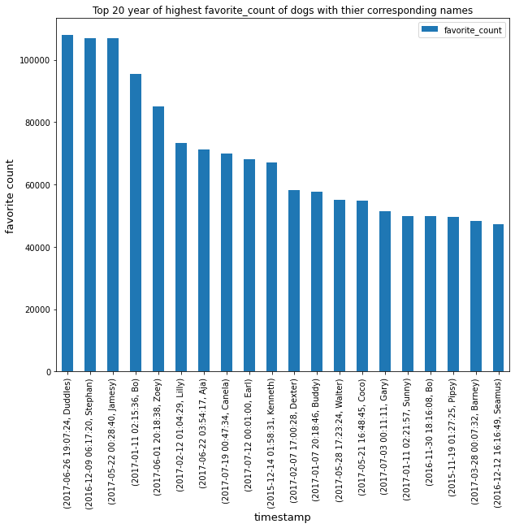